# Hockey Match Report

Analyst’s Diary Match Report

# Austria vs Hungary

**17 May 2026**  
IIHF World Championship 2026 – Group Stage

Austria (AUT) 4:2 Hungary (HUN)

Report generated from the match shot-location pipeline. Metrics marked as proxies are based on OCR-extracted shot coordinates and should be interpreted as transparent spatial indicators rather than official tracking data.

Prepared by Antonin Kremenak

# Executive summary

- Austria generated the higher official shots-on-goal volume.
- Austria produced the stronger location-based Shot Quality Index.
- Austria got more attempts from the inner-slot / high-danger area.
- Austria led in high-danger chances based on the distance-and-lane proxy.

Shots On Goal

AUT: 22 | HUN: 19

Blocked Shots

AUT: 9 | HUN: 13

Scoring Chances

AUT: 9 | HUN: 7

# 1. Public layer: simple match metrics

These visuals are designed as a simple entry point for wider audiences: official shots on goal, blocked shots, shot quality proxies and basic chance creation.

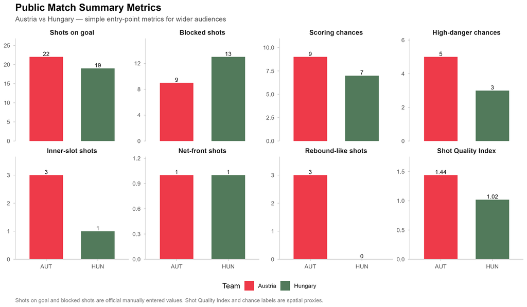

Key Metrics: Austria vs Hungary

17 May 2026 — Shot Quality Index is a location-based proxy, not a trained xG model.

| Metric | AUT | HUN |
| --- | --- | --- |
| OCR detected attempts | 22.00 | 17.00 |
| Corsi attempts | 22.00 | 17.00 |
| Fenwick attempts | 19.00 | 10.00 |
| Scoring chances | 9.00 | 7.00 |
| High-danger chances | 5.00 | 3.00 |
| Shot Quality Index | 1.44 | 1.02 |

# 2. Shot maps and spatial overview

Shot maps show where attempts came from, how dangerous they were spatially, and how shot locations changed across periods.

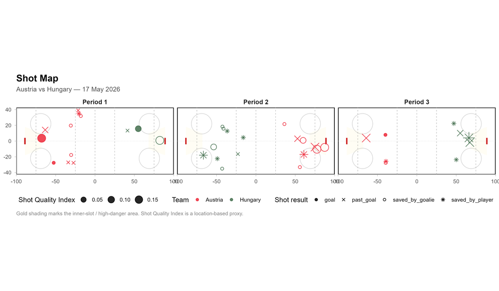

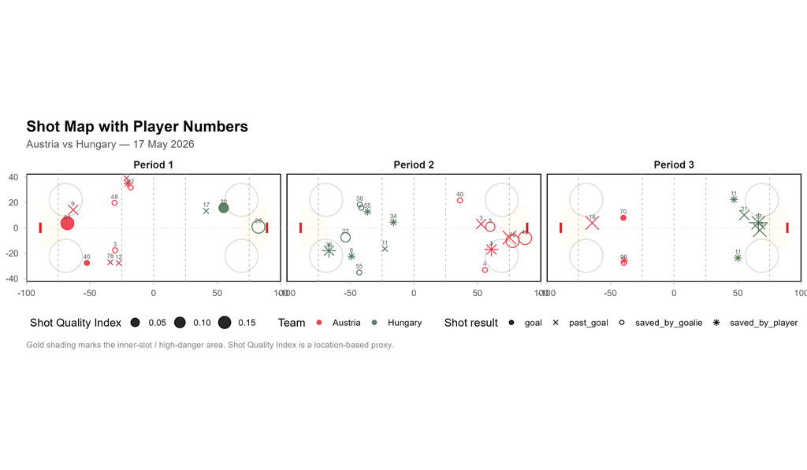

# 3. Shot quality and territorial battle

This section moves from simple shot counts to spatial pressure: location quality, offensive-zone density and period-by-period territorial advantage.

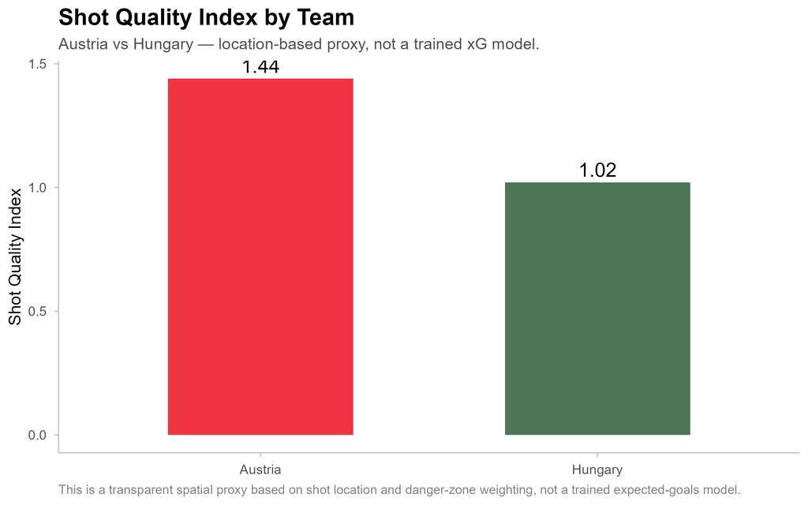

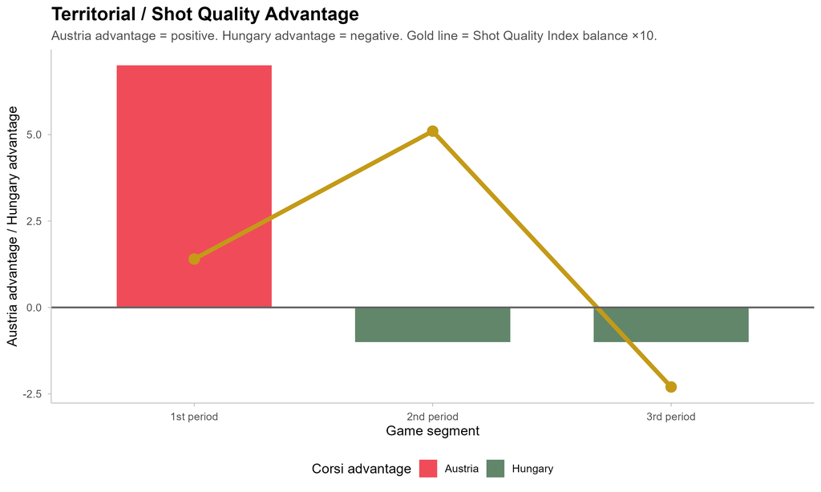

# 4. Offensive-zone density

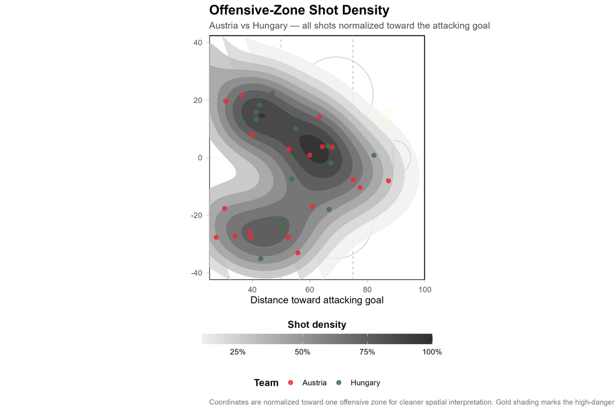

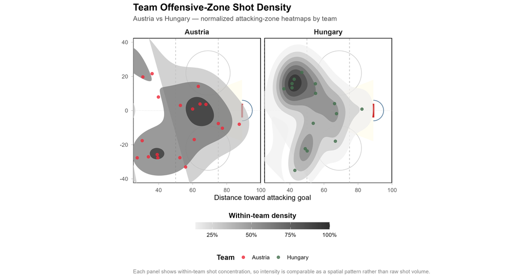

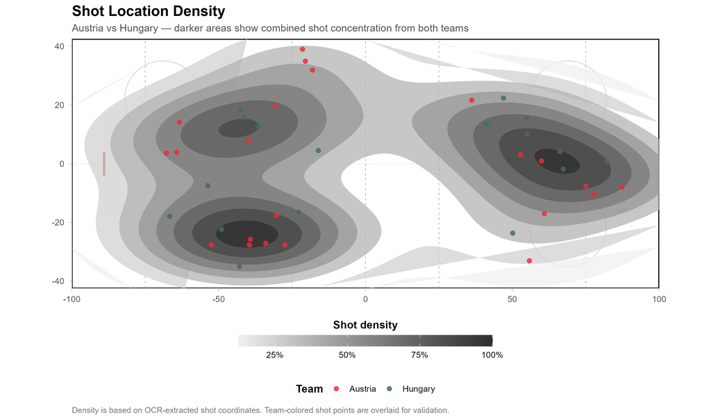

# 5. Advanced insider layer

The following metrics are proxy-based insider indicators built from the available shot-location sample. They are useful for storytelling, but they are not a substitute for full play-by-play or tracking data.

- Austria showed the highest aggression profile while leading, based on chance rate, slot access and net-front pressure.
- Austria had the strongest danger-oriented shot style: perimeter / point-shot oriented.
- Austria generated the clearest central-access pattern: strong central-lane access.
- Austria produced the strongest pressure window between shot sequence 19 and 24.
- Austria had the highest goals-per-SQI finishing efficiency and finished well above spatial chance quality.

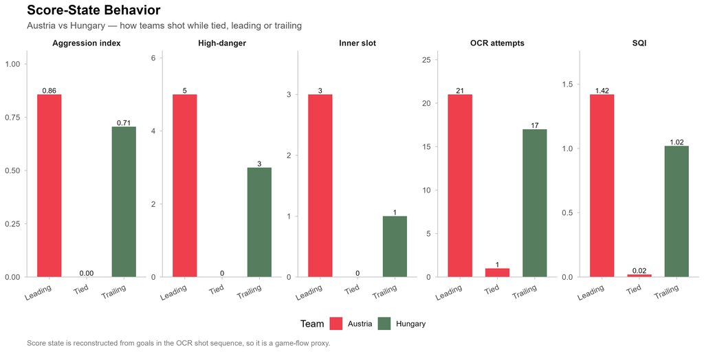

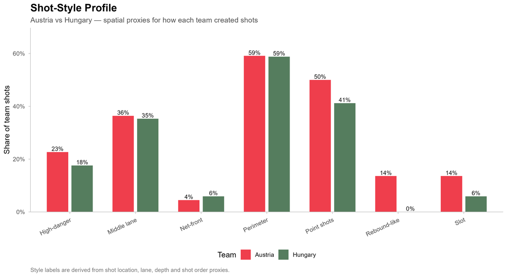

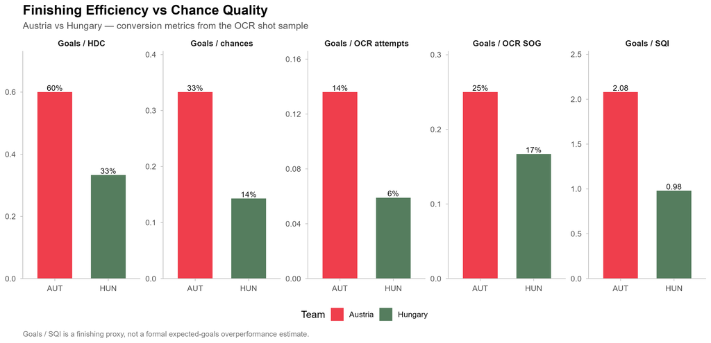

# 6. Momentum

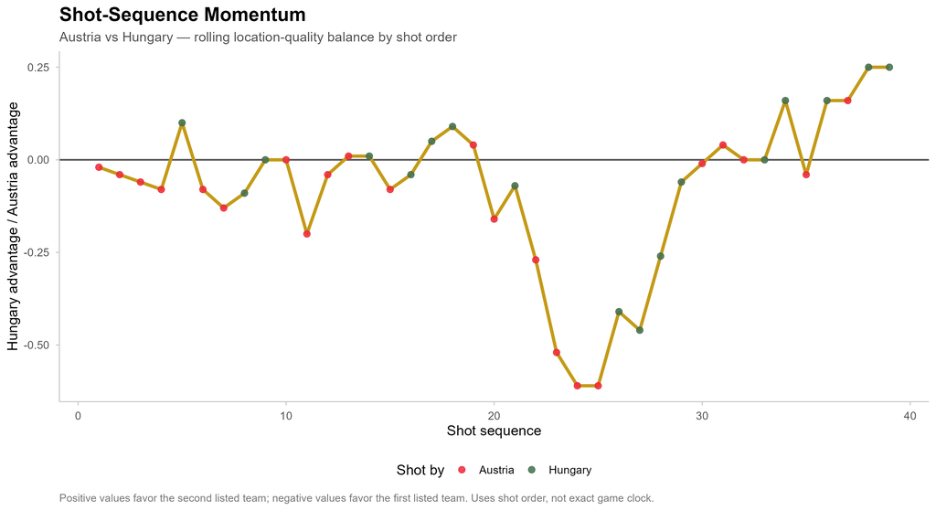

# 7. Player layer

**Player public leaders**

Top players from the OCR-extracted shot sample

| team | player_no | shots | goals | ocr_shots_on_goal | scoring_chances | high_danger_chances | inner_slot_shots | net_front_shots | rebound_like_shots | shot_quality_index | avg_shot_distance |
| --- | --- | --- | --- | --- | --- | --- | --- | --- | --- | --- | --- |
| AUT | 70 | 3 | 1 | 2 | 2 | 2 | 2 | 0 | 1 | 0.38 | 27.1 |
| AUT | 3 | 4 | 0 | 2 | 3 | 0 | 0 | 0 | 0 | 0.23 | 39.9 |
| AUT | 40 | 3 | 1 | 3 | 1 | 1 | 1 | 1 | 1 | 0.22 | 37.0 |
| HUN | 17 | 2 | 0 | 0 | 1 | 1 | 0 | 0 | 0 | 0.20 | 36.4 |
| AUT | 01 | 1 | 1 | 1 | 1 | 1 | 0 | 0 | 0 | 0.18 | 21.5 |
| AUT | 16 | 1 | 0 | 0 | 1 | 1 | 0 | 0 | 0 | 0.18 | 25.0 |
| HUN | 28 | 1 | 0 | 1 | 1 | 1 | 1 | 1 | 0 | 0.18 | 6.7 |
| HUN | 48 | 1 | 0 | 0 | 1 | 1 | 0 | 0 | 0 | 0.18 | 21.7 |
| HUN | 36 | 3 | 0 | 2 | 1 | 0 | 0 | 0 | 0 | 0.11 | 43.0 |
| AUT | 9 | 1 | 0 | 0 | 1 | 0 | 0 | 0 | 1 | 0.07 | 29.3 |
| HUN | 20 | 1 | 1 | 1 | 1 | 0 | 0 | 0 | 0 | 0.07 | 37.5 |
| HUN | 21 | 1 | 0 | 0 | 1 | 0 | 0 | 0 | 0 | 0.07 | 35.4 |

#Source https://www.iihf.com/en/events/2026/wm/schedule